# Gender and Star Wars Fandom: A Cross-Sectional Analysis

Juliet Chin

## Introduction

Does gender shape whether someone proudly calls themselves a Star Wars fan? In this project, I explore whether men and women differ in how likely they are to identify as fans of one of the world’s most iconic sci-fi franchises. My hypothesis is simple: men may be more likely than women to identify as Star Wars fans.

Why might this be the case? For decades, science fiction has often been marketed more heavily toward men, from action figures to blockbuster promotions. If boys and men are more frequently encouraged to engage with sci-fi media, they may also be more likely to incorporate fandom into their identity. In other words: are men genuinely more likely to identify as Star Wars fans, or have they just been socially nudged toward that galaxy far, far away?

Using survey data, this project examines whether this gender gap appears in real responses and whether gender meaningfully predicts Star Wars fandom.

## Data

This project uses data from FiveThirtyEight’s 2014 nationally distributed Star Wars survey, conducted online through SurveyMonkey Audience. The dataset includes 1,186 respondents and measures public opinions about Star Wars fandom, film preferences, and demographic characteristics such as gender and age. Because this survey captures respondents at one point in time rather than tracking them over time, this research design is cross-sectional. This means I can examine associations between demographic characteristics and Star Wars fandom, but I cannot determine direct causality.

My dependent variable is whether a respondent identifies as a Star Wars fan (Yes = 1, No = 0). My independent variable is gender, measured as Male or Female based on survey responses. I hypothesize that men will be more likely than women to identify as Star Wars fans. My hypothesis will be supported if men show a higher predicted probability of fandom and if the gender coefficient in my regression analysis is statistically significant.

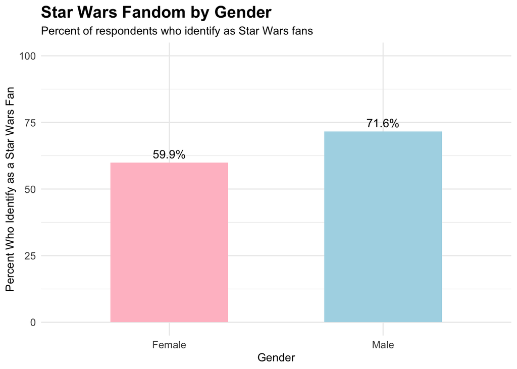

This plot shows the main outcome variable, Star Wars fandom, by gender. About 60 percent of women in the cleaned sample identify as Star Wars fans, compared to about 72 percent of men. This pattern supports my hypothesis descriptively because men report higher levels of Star Wars fandom than women.

## Results

Logistic Regression Predicting Star Wars Fandom

| Term | Estimate | Standard Error | P-value |
| --- | --- | --- | --- |
| Intercept | 0.403 | 0.102 | <0.001 |
| Male | 0.523 | 0.149 | <0.001 |

The descriptive bar chart provides an initial look at the relationship between gender and Star Wars fandom. In the cleaned sample, about 59.9 percent of women identify as Star Wars fans, compared to 71.6 percent of men. This suggests a noticeable gender gap, with men reporting higher fandom rates than women. Descriptively, this pattern supports my hypothesis that men are more likely than women to identify as Star Wars fans.

To test whether this relationship remains statistically meaningful, I ran a logistic regression using fan identity (1 = fan, 0 = not a fan) as the outcome and gender (1 = Male, 0 = Female) as the predictor. The coefficient for male respondents is positive (B = 0.523) and statistically significant (p < 0.001), meaning men are significantly more likely than women to identify as Star Wars fans even after formally modeling the relationship. In substantive terms, men have approximately 1.69 times greater odds of identifying as fans than women. This means gender is not just descriptively associated with fandom, but also a statistically meaningful predictor in this dataset.

However, this finding should not be interpreted as evidence that gender itself causes Star Wars fandom. Because this project relies on cross-sectional survey data, it cannot determine whether gender directly produces fandom differences or whether other factors, such as childhood media exposure, cultural expectations, genre marketing, or broader entertainment preferences, may also shape this pattern. In other words, gender may capture broader social influences rather than acting as a direct causal force.

## Additional Analysis

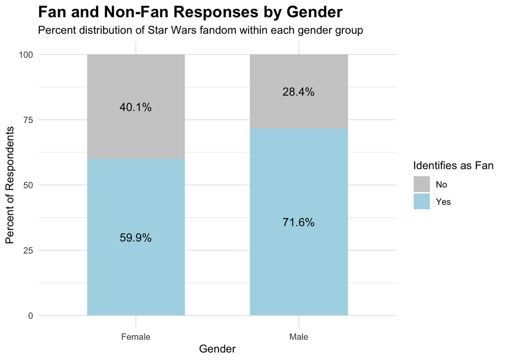

The additional stacked bar chart provides more context by showing both fan and non-fan responses within each gender category. While men are more likely than women to identify as fans, women still demonstrate substantial engagement, with nearly 60 percent identifying as Star Wars fans. This suggests the gender gap is meaningful, but not absolute. Rather than showing that women are uninterested in Star Wars, this visualization suggests that both groups participate heavily, though men do so at somewhat higher rates. This deeper breakdown strengthens the analysis by showing that gender influences the likelihood of fandom without fully determining it.

## Age and Gender Analysis

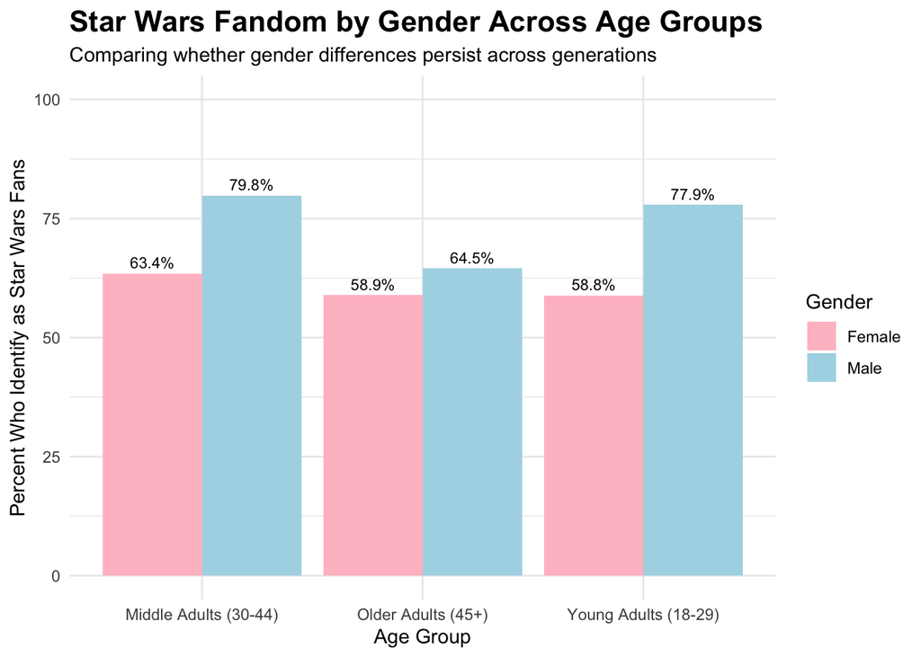

This age-and-gender comparison adds a deeper layer to the project by showing that the relationship between gender and Star Wars fandom is not identical across generations. Among young adults (18–29), men are much more likely than women to identify as Star Wars fans (77.9% vs. 58.8%), suggesting one of the largest gender gaps in the sample. A similarly large gap appears among middle-aged adults (30–44), where 79.8% of men identify as fans compared to 63.4% of women. However, among older adults (45+), the gender gap narrows considerably: 64.5% of men and 58.9% of women identify as fans.

These patterns suggest that age may shape how gender relates to fandom. In younger and middle generations, gender differences are more pronounced, possibly reflecting stronger gendered media marketing or differences in socialization. In contrast, older respondents show more similar fandom rates across gender. This strengthens the project by suggesting that gender alone does not fully explain Star Wars fandom; instead, gender may interact with generational experiences and cultural exposure. In short, the “gender gap” in Star Wars fandom appears strongest among younger groups and weakest among older adults, making age a meaningful additional dimension.

## Conclusion

Overall, my findings support my hypothesis that men are more likely than women to identify as Star Wars fans. Both descriptive and statistical analyses consistently show that men report higher levels of fandom, and the regression results indicate this relationship is statistically significant. At the same time, the relatively high percentage of women who also identify as fans suggests that Star Wars fandom is widespread across genders, even if men report stronger identification overall. Because this analysis uses cross-sectional survey data and only includes gender as the primary predictor, it cannot establish causality and may omit important confounding variables such as age, socialization, or media exposure. Future research could improve this project by incorporating additional predictors, comparing generational trends, or examining how marketing and cultural norms shape fandom identity over time.